# Pharmaceutical Sales Analysis Notebook

#### This notebook is dedicated for the description of *pharmaceutical-sales.csv* dataset, which is available at:

#### https://www.kaggle.com/datasets/bakasas/pharmaceutical-sales/

## 1. Importing needed libraries and the dateset

```python
import pandas as pd
import numpy as np
import matplotlib.pyplot as plt
import seaborn as sns
%matplotlib inline
```

```python
data = pd.read_csv('pharmaceutical-sales.csv', sep = ';', index_col=['product_code', 'check_no'])
data.head()
```

| product_code | check_no | date | customer_id | customer_gender | customer_age | chain | store_code | store_name | category_1 | category_2 | category_3 | qty | sale |
| --- | --- | --- | --- | --- | --- | --- | --- | --- | --- | --- | --- | --- | --- |
| 13006 | 177911 | 24.10.2021 | 70478 | Woman | 40 | A | 8 | Name 8 | Medication | 1 | 27 | 0,15 | 9,75 |
| 8593 | 40144 | 13.09.2021 | 87806 | Woman | 41 | A | 0 | Name 0 | NonMedication | 4 | 56 | 0,032 | 133,65 |
| 11705 | 271220 | 20.11.2021 | 61579 | Woman | 28 | B | 7 | Name 7 | NonMedication | 12 | 172 | 1 | 2 784,38 |
| 10068 | 279977 | 21.11.2021 | 102389 | Woman | 48 | B | 5 | Name 5 | NonMedication | 3 | 49 | 1 | 1 386,00 |
| 6395 | 170982 | 22.10.2021 | 3396 | Woman | 40 | A | 3 | Name 3 | NonMedication | 13 | 183 | 10 | 371,25 |

## 2. Dataset overview

```python
data.shape
```

```
(116686, 12)
```

```python
data.describe()
```

|  | customer_id | customer_age | store_code | category_2 | category_3 |
| --- | --- | --- | --- | --- | --- |
| count | 116686.000000 | 116686.000000 | 116686.000000 | 116686.000000 | 116686.000000 |
| mean | 65892.503205 | 43.883525 | 3.920505 | 3.717370 | 60.743063 |
| std | 37722.358749 | 14.587512 | 2.557146 | 4.882389 | 65.231528 |
| min | 1.000000 | 3.000000 | 0.000000 | 0.000000 | 0.000000 |
| 25% | 32541.250000 | 32.000000 | 2.000000 | 1.000000 | 18.000000 |
| 50% | 67308.000000 | 41.000000 | 4.000000 | 1.000000 | 32.000000 |
| 75% | 97478.000000 | 54.000000 | 6.000000 | 4.000000 | 81.000000 |
| max | 130938.000000 | 97.000000 | 8.000000 | 18.000000 | 240.000000 |

```python
data.head()
```

| product_code | check_no | date | customer_id | customer_gender | customer_age | chain | store_code | store_name | category_1 | category_2 | category_3 | qty | sale |
| --- | --- | --- | --- | --- | --- | --- | --- | --- | --- | --- | --- | --- | --- |
| 13006 | 177911 | 24.10.2021 | 70478 | Woman | 40 | A | 8 | Name 8 | Medication | 1 | 27 | 0,15 | 9,75 |
| 8593 | 40144 | 13.09.2021 | 87806 | Woman | 41 | A | 0 | Name 0 | NonMedication | 4 | 56 | 0,032 | 133,65 |
| 11705 | 271220 | 20.11.2021 | 61579 | Woman | 28 | B | 7 | Name 7 | NonMedication | 12 | 172 | 1 | 2 784,38 |
| 10068 | 279977 | 21.11.2021 | 102389 | Woman | 48 | B | 5 | Name 5 | NonMedication | 3 | 49 | 1 | 1 386,00 |
| 6395 | 170982 | 22.10.2021 | 3396 | Woman | 40 | A | 3 | Name 3 | NonMedication | 13 | 183 | 10 | 371,25 |

```python
data.info()
```

```
<class 'pandas.core.frame.DataFrame'>
MultiIndex: 116686 entries, (13006, 177911) to (6895, 192794)
Data columns (total 12 columns):
 #   Column           Non-Null Count   Dtype
---  ------           --------------   -----
 0   date             116686 non-null  object
 1   customer_id      116686 non-null  int64
 2   customer_gender  116686 non-null  object
 3   customer_age     116686 non-null  int64
 4   chain            116686 non-null  object
 5   store_code       116686 non-null  int64
 6   store_name       116686 non-null  object
 7   category_1       116686 non-null  object
 8   category_2       116686 non-null  int64
 9   category_3       116686 non-null  int64
 10  qty              116686 non-null  object
 11  sale             116686 non-null  object
dtypes: int64(5), object(7)
memory usage: 14.4+ MB
```

Its clear than there are no null values. However,**'date'**, **'qty'** and **'sale'** columns are not of the right data type.

## 3. Dataset cleansing

### Adjusting columns data types

```python
data2 = pd.read_csv('pharmaceutical-sales.csv', sep = ';', index_col=['product_code', 'check_no'])
```

Its preferable to copy data to another dataframe to keep original data intact. The columns **'qty'** and **'sale'** should be proberly adjusted for sake of changing their data type to float.

```python
data2['qty'] = data2['qty'].replace(',', '.', regex = True)
data2['qty'] = data2['qty'].replace(' ', '', regex = True)
data2['sale'] = data2['sale'].replace(',', '.', regex = True)
data2['sale'] = data2['sale'].replace(' ', '', regex = True)

data2.head()
```

| product_code | check_no | date | customer_id | customer_gender | customer_age | chain | store_code | store_name | category_1 | category_2 | category_3 | qty | sale |
| --- | --- | --- | --- | --- | --- | --- | --- | --- | --- | --- | --- | --- | --- |
| 13006 | 177911 | 24.10.2021 | 70478 | Woman | 40 | A | 8 | Name 8 | Medication | 1 | 27 | 0.15 | 9.75 |
| 8593 | 40144 | 13.09.2021 | 87806 | Woman | 41 | A | 0 | Name 0 | NonMedication | 4 | 56 | 0.032 | 133.65 |
| 11705 | 271220 | 20.11.2021 | 61579 | Woman | 28 | B | 7 | Name 7 | NonMedication | 12 | 172 | 1 | 2784.38 |
| 10068 | 279977 | 21.11.2021 | 102389 | Woman | 48 | B | 5 | Name 5 | NonMedication | 3 | 49 | 1 | 1386.00 |
| 6395 | 170982 | 22.10.2021 | 3396 | Woman | 40 | A | 3 | Name 3 | NonMedication | 13 | 183 | 10 | 371.25 |

```python
data2['qty'] = pd.to_numeric(data2['qty'], errors='coerce')
data2['sale'] = pd.to_numeric(data2['sale'], errors='coerce')
```

**'date' column also should be adjusted.**

```python
data2.date = pd.to_datetime(data2.date, format = "%d.%m.%Y")
```

```python
data2.info()
```

```
<class 'pandas.core.frame.DataFrame'>
MultiIndex: 116686 entries, (13006, 177911) to (6895, 192794)
Data columns (total 12 columns):
 #   Column           Non-Null Count   Dtype
---  ------           --------------   -----
 0   date             116686 non-null  datetime64[ns]
 1   customer_id      116686 non-null  int64
 2   customer_gender  116686 non-null  object
 3   customer_age     116686 non-null  int64
 4   chain            116686 non-null  object
 5   store_code       116686 non-null  int64
 6   store_name       116686 non-null  object
 7   category_1       116686 non-null  object
 8   category_2       116686 non-null  int64
 9   category_3       116686 non-null  int64
 10  qty              116686 non-null  float64
 11  sale             116007 non-null  float64
dtypes: datetime64[ns](1), float64(2), int64(5), object(4)
memory usage: 14.4+ MB
```

### **The next step is to remove null values.**

```python
data2.isna().sum()
```

```
date                 0
customer_id          0
customer_gender      0
customer_age         0
chain                0
store_code           0
store_name           0
category_1           0
category_2           0
category_3           0
qty                  0
sale               679
dtype: int64
```

```python
data2.dropna(subset=['sale'], inplace = True)
data2.info()
```

```
<class 'pandas.core.frame.DataFrame'>
MultiIndex: 116007 entries, (13006, 177911) to (6895, 192794)
Data columns (total 12 columns):
 #   Column           Non-Null Count   Dtype
---  ------           --------------   -----
 0   date             116007 non-null  datetime64[ns]
 1   customer_id      116007 non-null  int64
 2   customer_gender  116007 non-null  object
 3   customer_age     116007 non-null  int64
 4   chain            116007 non-null  object
 5   store_code       116007 non-null  int64
 6   store_name       116007 non-null  object
 7   category_1       116007 non-null  object
 8   category_2       116007 non-null  int64
 9   category_3       116007 non-null  int64
 10  qty              116007 non-null  float64
 11  sale             116007 non-null  float64
dtypes: datetime64[ns](1), float64(2), int64(5), object(4)
memory usage: 14.3+ MB
```

**All null values removed!**

### **Removing Outliers**

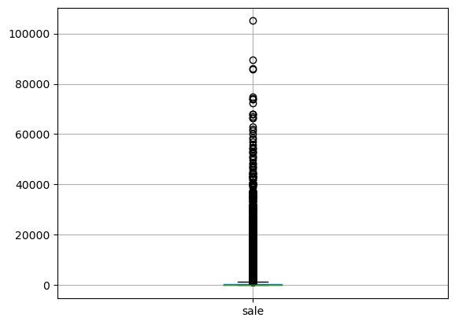

```python
boxplot = data2.boxplot( column = ['sale'])
```

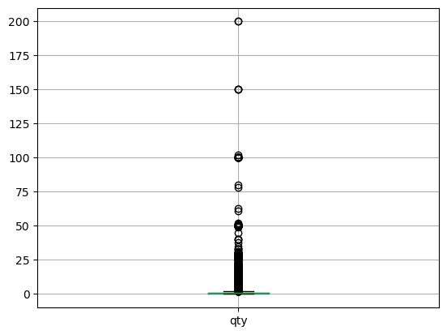

```python
boxplot = data2.boxplot( column = ['qty'])
```

**The outlies data should be assessed and counted to determine the effect of their removal on data integrity.**

```python
from scipy import stats
```

```python
qty_z = np.abs(stats.zscore(data2['qty']))
sale_z = np.abs(stats.zscore(data2['sale']))
```

```python
print('Number of rows in "qty" column with z-score more than 2: {}'.format((qty_z > 2).sum()))
print('Number of rows in "sale" column with z-score more than 2: {}'.format((sale_z > 2).sum()))
print('Number of total rows that should be deleted: {}'.format(len(data2.index[np.where((qty_z > 2) | (sale_z > 2))])))
```

```
Number of rows in "qty" column with z-score more than 2: 1676
Number of rows in "sale" column with z-score more than 2: 3965
Number of total rows that should be deleted: 5615
```

**Those rows could be removed, relatively to the data size.**

```python
data2.drop(data2.index[np.where((qty_z > 2) | (sale_z > 2))], inplace = True)
```

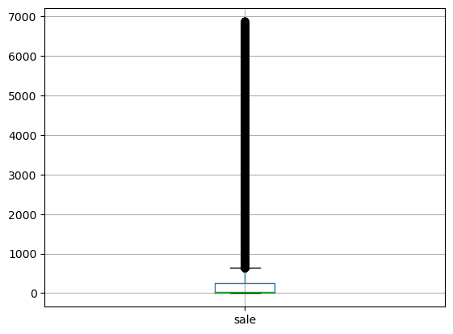

```python
 data2.boxplot( column = ['sale'])
```

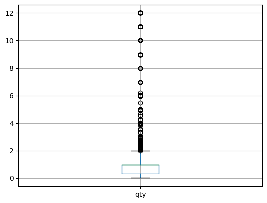

```python
data2.boxplot( column = ['qty'])
```

**Still there are outliers in the data, which declares the necessity of further investigation of these outliers.**

```python
data3 = data2.copy()
```

```python
data3.drop(data3.query(' qty > 2 | sale > 800').index, inplace = True)
data3.shape
```

```
(83266, 12)
```

### **Removing Duplicates**

```python
data3.drop_duplicates(inplace = True)
data3.info()
```

```
<class 'pandas.core.frame.DataFrame'>
MultiIndex: 83170 entries, (13006, 177911) to (1369, 221204)
Data columns (total 12 columns):
 #   Column           Non-Null Count  Dtype
---  ------           --------------  -----
 0   date             83170 non-null  datetime64[ns]
 1   customer_id      83170 non-null  int64
 2   customer_gender  83170 non-null  object
 3   customer_age     83170 non-null  int64
 4   chain            83170 non-null  object
 5   store_code       83170 non-null  int64
 6   store_name       83170 non-null  object
 7   category_1       83170 non-null  object
 8   category_2       83170 non-null  int64
 9   category_3       83170 non-null  int64
 10  qty              83170 non-null  float64
 11  sale             83170 non-null  float64
dtypes: datetime64[ns](1), float64(2), int64(5), object(4)
memory usage: 11.2+ MB
```

Fortunately, the data didn't include many duplicates.

## 4. Calculation of summary statistics

**Average sales amount and quantity of sold items per check:**

```python
print('Average sales amount per check::{}'.format(round(data3.groupby('check_no').sale.sum().mean(),2)))
print('Average quantity of sold items per check::{}'.format(round(data3.groupby('check_no').qty.count().mean(),2)))
```

```
Average sales amount per check::74.02
Average quantity of sold items per check::1.17
```

**Median, mode and standard deviation of the check amounts:**

```python
print('Median of check amount:{}'.format(data3.groupby('check_no').sale.sum().median()))
print('Mode of check amount:{}'.format(data3.groupby('check_no').sale.sum().mode()[0]))
print('Standard deviation of check amount:{}'.format(data3.groupby('check_no').sale.sum().std()))
```

```
Median of check amount:24.07
Mode of check amount:33.41
Standard deviation of check amount:143.08535358235576
```

```python
print('Percent of medication sales: {}%'.format(round((data3.groupby('category_1')['sale'].sum()/data3.sale.sum()*100)[0],2)))
print('Percent of medication Quantity sold: {}%'.format(round((data3.groupby('category_1')['qty'].sum()/data3.qty.sum()*100)[0],2)))
print('Percent of non-medication sales: {}%'.format(round((data3.groupby('category_1')['sale'].sum()/data3.sale.sum()*100)[1],2)))
print('Percent of non-medication quantity sold: {}%'.format(round((data3.groupby('category_1')['qty'].sum()/data3.qty.sum()*100)[1],2)))
```

```
Percent of medication sales: 45.23%
Percent of medication Quantity sold: 83.01%
Percent of non-medication sales: 54.77%
Percent of non-medication quantity sold: 16.99%
```

**Non-medication sales represent nearly 55% of sales, although 17% only of sold items.**